# Linear regression

FdR

29 December 2014

## Single variable.

y<sup>i</sup> = b_0 + b_1 x_1<sup>i</sup> + e<sup>i</sup>

## Multi-variables regression.

This post is an attempt to use this article from [Data Perspective](http://www.dataperspective.info/2014/10/regression-analysis-using-r.html) into a R Markdown document using, Github, ggplot2, dplyr, etc.

The article use the [data](https://archive.ics.uci.edu/ml/datasets/Combined+Cycle+Power+Plant) from a combine cycle power plant. Once downloaded and put in the right folder, we can start working on it. Because, it is a .xlsx, let’s first install the library, then load it.

```r
library(xlsx)
```

We then load the file. Because this .xlsx file has several index (tab), we have to specify which tab, we want to use.

```r
data = read.xlsx("Folds5x2_pp.xlsx", sheetIndex=1)
```

```r
head(data)
```

```
##      AT     V      AP    RH     PE
## 1 14.96 41.76 1024.07 73.17 463.26
## 2 25.18 62.96 1020.04 59.08 444.37
## 3  5.11 39.40 1012.16 92.14 488.56
## 4 20.86 57.32 1010.24 76.64 446.48
## 5 10.82 37.50 1009.23 96.62 473.90
## 6 26.27 59.44 1012.23 58.77 443.67
```

We can focus on the first column (AT ~ Average Temperature) Any missing data?

```r
sum(is.na(data$AT))
```

```
## [1] 0
```

The range of data?

```r
range(data$AT)
```

```
## [1]  1.81 37.11
```

Plot the distribution of values for AT.

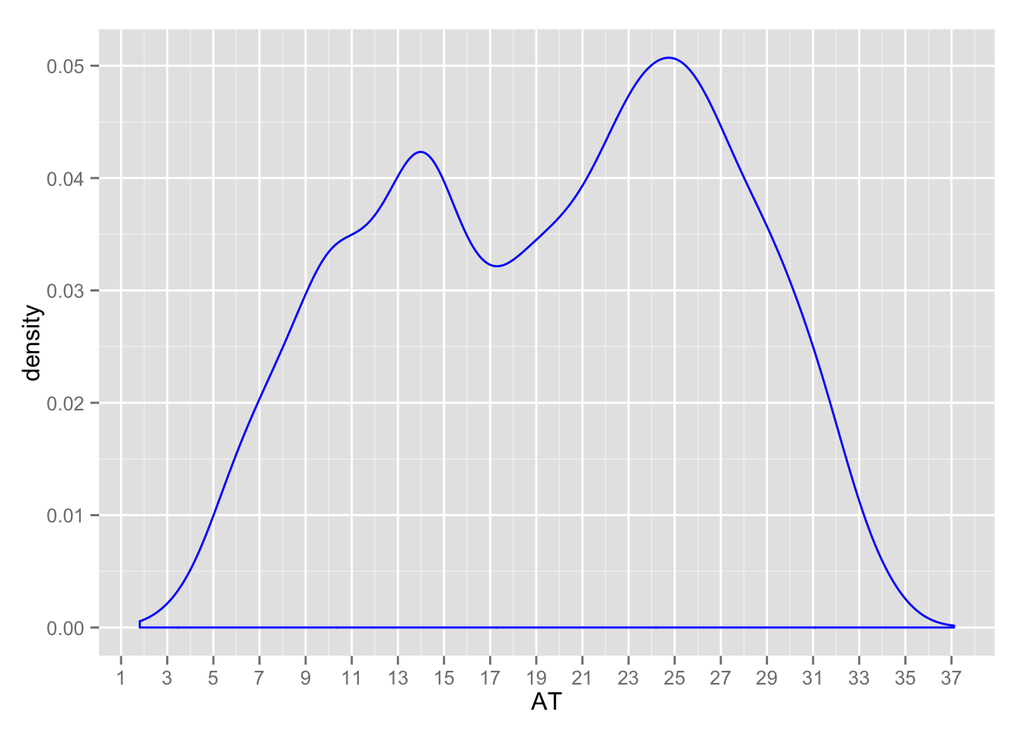

```r
library(ggplot2)
p1 = ggplot(data, aes(AT)) + geom_density(color="blue") + scale_x_continuous(breaks = seq(1,40,2))
p1
```

For a correlation analysis, we can run

```r
cor(data)
```

```
##            AT          V          AP          RH         PE
## AT  1.0000000  0.8441067 -0.50754934 -0.54253465 -0.9481285
## V   0.8441067  1.0000000 -0.41350216 -0.31218728 -0.8697803
## AP -0.5075493 -0.4135022  1.00000000  0.09957432  0.5184290
## RH -0.5425347 -0.3121873  0.09957432  1.00000000  0.3897941
## PE -0.9481285 -0.8697803  0.51842903  0.38979410  1.0000000
```

and see that the variables AT and PE are strongly negatively correlated.

When doing correlation analysis, one have to ensure that there aren’t any correlation amonth the independant variables.

While doing multiple regression analysis, it is always better (whenever possible) to split our data into a training set and a testing set. We can do this in the following way

```r
rand = data[sample(nrow(data)),]
training = rand[1:6500,]
testing = rand[6501:9568,]
```

Basically we shuffle all the row in the dataset `data`, then assign part of it to a training set, and another part to a testing set.

```r
model1 = lm(PE ~ AT+V+AP+RH, data = training)
summary(model1)
```

```
##
## Call:
## lm(formula = PE ~ AT + V + AP + RH, data = training)
##
## Residuals:
##     Min      1Q  Median      3Q     Max
## -43.455  -3.204  -0.157   3.204  17.780
##
## Coefficients:
##               Estimate Std. Error  t value Pr(>|t|)
## (Intercept) 458.585610  11.739508   39.063  < 2e-16 ***
## AT           -1.978969   0.018550 -106.681  < 2e-16 ***
## V            -0.233523   0.008896  -26.249  < 2e-16 ***
## AP            0.058212   0.011389    5.111 3.29e-07 ***
## RH           -0.158514   0.005010  -31.641  < 2e-16 ***
## ---
## Signif. codes:  0 '***' 0.001 '**' 0.01 '*' 0.05 '.' 0.1 ' ' 1
##
## Residual standard error: 4.552 on 6495 degrees of freedom
## Multiple R-squared:  0.9292, Adjusted R-squared:  0.9291
## F-statistic: 2.131e+04 on 4 and 6495 DF,  p-value: < 2.2e-16
```

```r
pred = predict(model1, testing[,1:4])
```